# What Lead Left Behind

Hannah Bensen hannahbensen7@gmail.com

2025-06-07

Though child Blood Lead Levels (BLL) have trended down in the in the last few decades, the CDC [estimates](https://www.cdc.gov/lead-prevention/php/news-features/updates-blood-lead-reference-value.html#:~:text=The%20BLRV%20is%20a%20population,the%20need%20for%20exposure%20prevention.) that around 500,000 children U.S. children aged 1-5 (about 2.5% of this population) suffer from elevated BLL levels, defined as greater than 3.5 ug/dL.

Elevated BLL in children can result in lower IQ, learning capacity, lifetime earnings, and other negative consequences. Further, lead-based paint poisoning - one of the most common sources of elevated BLL - is a preventable hazard that is highly related to historical inequities in housing policy.

[interactive chart not shown]

This story will evaluate Blood Lead Levels in specific states of interest including Maryland. It will consider how BLL is trending in different states and whether these trends are tied to a specific geography (such as Baltimore) a specific demographic group (such as Black communities or low-income people), or a particular source of lead (such as lead-based paint, industrialization, or environmental factors).

The state of Maryland has BLL data at the county level for 2023.

This story will also evaluate the efficacy of federal and state lead-abatement programs. Maryland, for example, has a few initiatives designed to track and mitigate child lead exposure:

1. A **mandatory lead testing program** implemented by state law in 2015 and 2016 requires all children at 12 months and 24 months to be tested for lead. This initiative has resulted in a higher percentage of lead testing, but still, 100% of kids are not tested - around one-third of one- and two-year-olds are currently tested. Further, many states do not have mandatory lead testing and thus suffer from a lack of available data or data quality issues.
2. Maryland has a [Healthy Homes](https://health.maryland.gov/phpa/OEHFP/EH/pages/healthy-homes.aspx) program focuses on identifying and eliminating health hazards for all residents. Maryland also has a [program](https://health.maryland.gov/phpa/OEHFP/EH/Pages/LeadHomeVisiting.aspx) that helps families who have children with BLL > 3.5 ug/dL remove lead from their homes at no cost to the homeowner or resident. *Possible story angle: Are these programs effective? Why or why not? How do different state initiatives compare to one another, and which are most effective?*
3. [Maryland’s Reduction of Lead Risk in Housing Act](https://www.peoples-law.org/lead-paint-law-information-owners-and-sellers#landlord-duties) requires landlords who rent pre-1978 dwellings to register their properties, fulfill lead-free certification requirements, and pass a Lead Free inspection each time a tenant changes. *Possible story angle: Are landlords complying with this regulation? If not, which populations are being disproportionately impacted?*

**Note that for the purpose of this pitch, I will consider 5 µg/dL to be the threshold for “elevated” BLL because the CDC data only had data for 5 ug/dL and above for 2017 - 2021.**

*Context*  
The Centers for Disease Control and Prevention (CDC) has found that even a low blood lead level (BLL) can cause lifelong health effects. Before 2012, at or greater than **10 µg/dL** was the threshold for public intervention. In 2012, the threshold was changed to **5 ug/dL**, and in 2021, **3.5 ug/dL** became the new reference number. There is no safe level of lead in blood for children, the CDC says.

*Why now?*  
Children’s health and public health is always newsworthy. Further, federal budget cuts of health monitoring leads to more ambiguity around the causes and impacts of elevated BLL. Maryland’s department of the environment webpage, for example - which ostensibly was the place to obtain Maryland’s child blood lead level data - is not usable at the moment due to federal budget cuts.

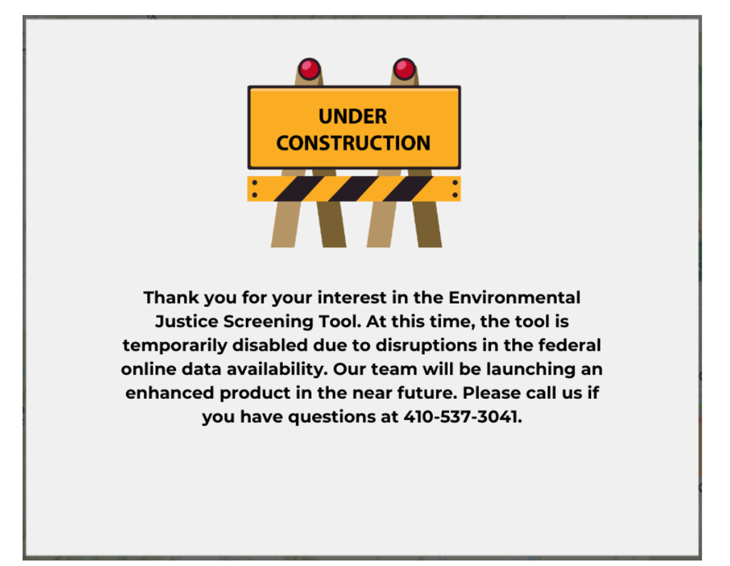

Maryland’s data warning on their website.

*Three sources*  
1. The Maryland Department of Environment’s Lead Registry Annual Surveillance Report contains data for Maryland on blood lead tests done in the state. Reports go back until at least 2010, if not earlier. [Here](https://mde.maryland.gov/programs/land/LeadPoisoningPrevention/Documents/2023%20MDE%20Lead%20Poisoning%20Prevention%20Program%20Surveillance%20Report.pdf) is the 2023 report.  
2. The Maryland Department of Health released a [2022 Report](https://health.maryland.gov/phpa/OEHFP/EH/Documents/MDLeadTestingEvaluation_122022.pdf) evaluating the policy impact of Maryland’s universal childhood blood lead testing requirement. The report also provides useful information on what Maryland is doing to mitigate elevated blood levels, the impact of lead in children, and sources of lead in Maryland (mainly lead paint from pre-1979 homes)  
3. A Congressional Research Service report from 2013 titled “[Lead-Based Paint Poisoning Prevention: Summary of Federal Mandates and Financial Assistance for Reducing Hazards in Housing](https://www.congress.gov/crs-product/RS21688?q=%7B%22search%22%3A%22blood+lead+level%22%7D&s=1&r=8)” outlines federal legislative efforts to mitigate lead-based paint poisoning.

*Potential Impact*  
Elevated BLL levels in children can result in lower IQ, lifetime earnings, and other negative consequences. According to Maryland’s department of health report, lead paint is a preventable hazard that is “highly related to historical inequities in housing policy.” This story could impact policy if localities are not complying with state and federal law.

It will also spotlight factors or policies driving the decrease in BLL levels in the above timeframe. Generally speaking, the factors driving declining BLL levels in children in states across the country are driven by a combination of successful federal regulations, dedicated state and local prevention programs, improved surveillance and case management, and increased public awareness regarding lead exposure and prevention.

*Surprising Findings*

The states with the biggest percentage drops in children with BLL at or above 5 ug/dl from 2017 to 2021 are the following. Only two states - Florida and South Carolina - saw an increase in the percentage of children with elevated BLL between 2017 and 2021.

[interactive chart not shown]

The states with the highest *number* of children with elevated BLL are shown below. Note that states with a bigger population will have a higher number of children with elevated BLL.

[interactive chart not shown]

The states with the highest *percentage* of children with BLL at or above 5 ug/dL in 2021 are:  
1. Rhode Island  
2. New Jersey  
3. Wisconsin  
4. New Hampshire  
5. Connecticut

# Load software libraries

```r
#install.packages("tidyverse")
#install.packages("janitor")
#install.packages("readxl")
#install.packages("rvest")
#install.packages("viridis")
library(tidyverse)
library(janitor)
library(readxl)
library(rvest)
library(ggplot2)
library(dplyr)
library(viridis)
library(maps)
library(ellmer)
```

# Load your data

2024 CBLS Data

```r
 df_raw <- read_excel("../data/cbls-national-data-508.xlsx", skip=2, n_max = 270) %>%
      clean_names()

#df_raw <- read_excel("../data/cbls-national-data-508.xlsx", skip =2, n_max = 270)
```

# Obtain data

```r
#Upload screenshot of Maryland's Blood Level Level data from their 2023 Lead Registry Report
BLL23 <- google_upload(path = "/Users/hannahbensen/code/hannah-bensen/data/BLL_2023.png")
```

```r
#Use LLM to extract data from 2023 Maryland surveillance report
#Commented out becuase I copy the output into a dataframe in a code chunk below.
# Set the model BLL_2023.png
# gemini_chat <- chat_google_gemini(model="gemini-2.5-flash-preview-04-17")
#
# extract_csv_gemini <- gemini_chat$chat("Could you extract the table called Table Five: Blood Lead Testing of Children 0-72 Months by Jurisdiction from this link? No yapping, just export the data such that it can be used in an R dataframe", BLL23)
```

```r
#Copy output from LLM into R, clean dataframe

text_data <- "
County,Population of Children,Number Tested,Percent Tested,Blood Lead Level >=5 ug/dL Incidence Number,Blood Lead Level >=5 ug/dL Incidence Percent,Blood Lead Level >=5 ug/dL Prevalence Number,Blood Lead Level >=5 ug/dL Prevalence Percent,Blood Lead Level 5-9 ug/dL Incidence Number,Blood Lead Level 5-9 ug/dL Incidence Percent,Blood Lead Level 5-9 ug/dL Prevalence Number,Blood Lead Level 5-9 ug/dL Prevalence Percent,Blood Lead Level >=10 ug/dL Incidence Number,Blood Lead Level >=10 ug/dL Incidence Percent,Blood Lead Level >=10 ug/dL Prevalence Number,Blood Lead Level >=10 ug/dL Prevalence Percent
Allegany,3280,1227,37.4,47,1.4,31,0.9,36,1.1,23,0.7,11,0.3,8,0.2
Anne Arundel,37364,10673,28.6,72,0.2,27,0.1,68,0.2,24,0.1,4,0.0,3,0.0
Baltimore,50559,17535,34.7,186,0.4,82,0.2,143,0.3,56,0.1,43,0.1,26,0.1
Baltimore City,35556,13859,39.0,363,1.0,195,0.5,297,0.8,153,0.4,66,0.2,42,0.1
Calvert,5429,1327,24.4,4,0.1,3,0.1,3,0.1,2,0.0,1,0.0,1,0.0
Caroline,2262,701,31.0,7,0.3,3,0.1,5,0.2,3,0.1,2,0.1,0,0.0
Carroll,10318,3113,30.2,51,0.5,23,0.2,41,0.4,13,0.1,10,0.1,10,0.1
Cecil,6305,1640,26.0,37,0.6,10,0.2,32,0.5,9,0.1,5,0.1,1,0.0
Charles,10291,2921,28.4,24,0.2,6,0.1,19,0.2,6,0.1,5,0.0,0,0.0
Dorchester,1893,562,29.7,10,0.5,9,0.5,8,0.4,8,0.4,2,0.1,1,0.1
Frederick,18486,5685,30.8,37,0.2,20,0.1,26,0.1,16,0.1,11,0.1,4,0.0
Garrett,1289,255,19.8,2,0.2,1,0.1,1,0.1,0,0.0,1,0.1,1,0.1
Harford,14994,4547,30.3,27,0.2,16,0.1,22,0.1,13,0.1,5,0.0,3,0.0
Howard,18807,4274,22.7,36,0.2,21,0.1,28,0.1,15,0.1,8,0.0,6,0.0
Kent,786,200,25.4,5,0.6,3,0.4,3,0.4,2,0.3,2,0.3,1,0.1
Montgomery,63134,23308,36.9,147,0.2,70,0.1,106,0.2,51,0.1,41,0.1,19,0.0
Prince George's,56767,21134,37.2,134,0.2,51,0.1,111,0.2,45,0.1,23,0.0,6,0.0
Queen Anne's,29523,907,3.1,5,0.0,2,0.0,4,0.0,1,0.0,1,0.0,1,0.0
Saint Mary's,7464,2215,29.7,11,0.1,4,0.1,10,0.1,3,0.0,1,0.0,1,0.0
Somerset,1148,440,38.3,8,0.7,7,0.6,5,0.4,4,0.3,3,0.3,3,0.3
Talbot,1865,463,24.8,7,0.4,3,0.2,5,0.3,3,0.2,2,0.1,0,0.0
Washington,8863,2536,28.6,45,0.5,23,0.3,34,0.4,15,0.2,11,0.1,8,0.1
Wicomico,6811,2603,38.2,44,0.6,19,0.3,37,0.5,14,0.2,7,0.1,5,0.1
Worcester,2357,831,35.3,9,0.4,2,0.1,8,0.3,2,0.1,1,0.0,0,0.0
Statewide,371258,122956,33.1,1318,0.4,631,0.2,1052,0.3,481,0.1,266,0.1,150,0.0
"

bll_df <- read.csv(textConnection(text_data), check.names = FALSE)

#Select variables of interest
bll_chart <- bll_df %>%
  select(County,
         `Blood Lead Level >=5 ug/dL Incidence Percent`,
         `Blood Lead Level 5-9 ug/dL Incidence Percent`,
         `Blood Lead Level >=10 ug/dL Incidence Percent`
         ) %>%
  mutate(County = case_when(
    County == "Saint Mary's" ~ "St. Mary's",
    County == "Baltimore" ~ "Baltimore County",
    TRUE ~ County))
```

```r
#Write dataframes
readr::write_csv(bll_df, file = "/Users/hannahbensen/code/hannah-bensen/data/BLL_2023.csv")
readr::write_csv(bll_chart, file = "/Users/hannahbensen/code/hannah-bensen/data/BLL_chart_2023.csv")
```

# Clean CBLS national data

```r
 df_5BLL <- df_raw %>%
  #Make Year numeric
  mutate(#replace all "SDs" with 1. "SD - Indicates non-zero counts fewer than 6 have been suppressed to protect confidentiality." So SD equals something between 1 and 6. Converting to 1 is a conservative estimate
         across(everything(), ~ifelse(. == "SD", 1, .)),
         across(everything(), ~ifelse(. == "-", NA, .))) %>%
  mutate(year = as.numeric(str_extract_all(year, "[0-9]+")),
         across(-state, as.numeric)) %>%
  rowwise() %>% # Apply the sum row by row
  mutate(min5BLL = sum(c(number_of_children_with_confirmed_bl_ls_5_mg_d_l,
                         number_of_children_with_confirmed_bl_ls_10_mg_d_l,
                         number_of_children_with_confirmed_bl_ls_5_9_mg_d_l,
                         number_of_children_with_confirmed_bl_ls_15_19_mg_d_l,
                         number_of_children_with_confirmed_bl_ls_25_44_mg_d_l), na.rm = TRUE)) %>%
  ungroup() %>%
  mutate(min5BLL_pct = min5BLL/number_of_children_tested_72_months_of_age *100) %>%
  #Select key variables
  select(c(year, state, min5BLL, min5BLL_pct, number_of_children_tested_72_months_of_age)) %>%
  mutate(min5BLL = na_if(min5BLL, 0))
```

```r
# Calculate the percentage difference
df_diff <- df_5BLL %>%
  # Group by state so calculations are done independently for each state
  group_by(state) %>%
  # Use summarise to create new rows for each state with the calculated difference
  summarise(
    # Get the min5BLL value for 2017
    min5BLL_2017 = min5BLL[year == 2017],
    # Get the min5BLL value for 2021
    min5BLL_2021 = min5BLL[year == 2021],
    # Calculate the percentage difference
    # Formula: ((Value_2021 - Value_2017) / Value_2017) * 100
    # If either 2017 or 2021 value is NA, the difference will also be NA
    pct_diff = ((min5BLL_2021 - min5BLL_2017) / min5BLL_2017) * 100
  ) %>%
  # Ungroup the data frame if you plan to do further operations on the whole frame
  ungroup() %>%
  filter(pct_diff != -100) %>%
  arrange(pct_diff)
```

# Data exploration: states with most dangerous levels

The states with the highest percentage of children with confirmed BLL over the 5 µg/dL in 2021 are: Rhode Island, New Jersey, New Hampshire, Wisconsin, and Connecticut

```r
df_5BLL_2021 <- df_5BLL %>%
  #Filter for most recent year in dataset
  filter(year == 2021) %>%
  #Remove rows with missing values
  subset(!is.na(min5BLL_pct)) %>%
  arrange(desc(min5BLL_pct)) %>%
  mutate(min5BLL_pct = round(min5BLL_pct, 2))

df_5BLL_2021_top <- df_5BLL_2021 %>%
  select(state, min5BLL) %>%
  arrange(desc(min5BLL)) %>%
  filter(state != "U.S. Totals ǁ") %>%
  head(10)


head(df_5BLL_2021, 10)
```

```
## # A tibble: 10 × 5
##     year state         min5BLL min5BLL_pct number_of_children_tested_72_months…¹
##    <dbl> <chr>           <dbl>       <dbl>                                 <dbl>
##  1  2021 Rhode Island     1074        5.67                                 18936
##  2  2021 New Jersey       2344        5.44                                 43117
##  3  2021 Wisconsin        2563        3.98                                 64370
##  4  2021 New Hampshire     642        3.93                                 16321
##  5  2021 Connecticut      2149        3.8                                  56505
##  6  2021 Kansas            860        3.7                                  23254
##  7  2021 Missouri         2106        3.7                                  56956
##  8  2021 Illinois         5878        3.46                                170128
##  9  2021 New York        13190        3.14                                420687
## 10  2021 Delaware          276        3.04                                  9069
## # ℹ abbreviated name: ¹number_of_children_tested_72_months_of_age
```

```r
readr::write_csv( df_5BLL_2021, file = "/Users/hannahbensen/code/hannah-bensen/data/5BLL_counts_and_percents_2021.csv")
readr::write_csv( df_5BLL_2021_top, file = "/Users/hannahbensen/code/hannah-bensen/data/5BLL_top10_5BLLcounts_2021.csv")
```

# Questions

Write down questions you want answered:

What are the states that had the biggest decrease over 5 years - from 2017 to 2021 - in percentage of children with confirmed BLL over the 5 µg/dL?

```r
df_BLL_wide_counts <- df_5BLL %>%
  select(year, state, min5BLL) %>%
  filter(min5BLL>0) %>%
  #Widen df
  pivot_wider(names_from = "year",
              values_from = "min5BLL") %>%
  #select State and first and last year
  select(state, "2017", "2021") %>%
  #Drop missing values
  drop_na("2017", "2021") %>%
  #Calculate difference between 2021 and 2017
  mutate(diff_5BLL = `2021` - `2017`) %>%
  arrange(diff_5BLL)
```

#These states had the biggest decline in percentage of children with elevated BLL (over 5 µg/dL) from 2017 to 2021 in terms of the count (so, biggest states will be overrepresented).

```r
head(df_BLL_wide_counts, 5)  # Display the first 5 rows
```

```
## # A tibble: 5 × 4
##   state         `2017` `2021` diff_5BLL
##   <chr>          <dbl>  <dbl>     <dbl>
## 1 U.S. Totals ǁ 114057  66938    -47119
## 2 New York       20832  13190     -7642
## 3 New Jersey      7700   2344     -5356
## 4 Illinois        8501   5878     -2623
## 5 Wisconsin       4909   2563     -2346
```

#These two states had the biggest increase in percentage of children with elevated BL from 2017 to 2021 in terms of counts

```r
tail(df_BLL_wide_counts, 2)  # Display the last 5 rows
```

```
## # A tibble: 2 × 4
##   state          `2017` `2021` diff_5BLL
##   <chr>           <dbl>  <dbl>     <dbl>
## 1 South Carolina    702    754        52
## 2 Florida           609    701        92
```

#A better way of looking at these data are in percent increases in declines. These states had the biggest percentage point declines in the number children with elevated BLL between 2017 and 2017. Two states - South Carolina and Florida - had a percent increase in the number of children with elevated BLL.

```r
head(df_diff, 5)  # Display the last 5 rows
```

```
## # A tibble: 5 × 4
##   state      min5BLL_2017 min5BLL_2021 pct_diff
##   <chr>             <dbl>        <dbl>    <dbl>
## 1 Nevada              150           36    -76
## 2 New Jersey         7700         2344    -69.6
## 3 Alaska               58           29    -50
## 4 Wisconsin          4909         2563    -47.8
## 5 Michigan           4815         2559    -46.9
```

```r
tail(df_diff, 2)  # Display the last 5 rows
```

```
## # A tibble: 2 × 4
##   state          min5BLL_2017 min5BLL_2021 pct_diff
##   <chr>                 <dbl>        <dbl>    <dbl>
## 1 South Carolina          702          754     7.41
## 2 Florida                 609          701    15.1
```

```r
df_diff_export <- df_diff %>%
  select(state, pct_diff) %>%
  arrange(pct_diff) %>%
  slice_head(n = 10) %>%
  bind_rows(df_diff %>%
              select(state, pct_diff) %>%
              arrange(desc(pct_diff)) %>% slice_head(n = 2)) %>%
  mutate(pct_diff = round(pct_diff, 2))
```

```r
readr::write_csv( df_diff_export, file = "/Users/hannahbensen/code/hannah-bensen/data/states_with_highest_5BLL_percent.csv")
```